# Time Series Models

Jon Minton

2022-07-21

# Are annual ex time series random walks with drift (RWD) or do they have autocorrelation?

Different patterns of variation in the time series can be modelled using different specifications of the ARIMA modelling approach. ARIMA stands for Autoregressive (AR), Integrated (I), Moving Average (MA), and different ARIMA specifications are represented by the shorthand ARIMA(p, d, q). The p term indicates the number of autoregressive terms, the d term the number of times the series have been differenced, and the q term the number of moving average terms.

In this appendix we are primarily interested in comparing the ARIMA(0, 1, 0) specification with the ARIMA(1, 1, 0) specification. The ARIMA(0, 1, 0) is known as Random-Walk-with-Drift (RWD) and is the simpler of the two specifications. ARIMA(1, 1, 0) includes one autoregressive term p, meaning for each value in the series there is some correlation with the previous value in the series. For this autoregressive term p, a positive coefficient may be interpreted as indicating some degree of ‘stickiness’ in the series (a better-than-average value is more likely than by chance to be followed by a better-than-average value, and vice versa), whereas a negative coefficient interpreted as indicating some degree of ‘oscillation’ in the series (a better-than-average value is more likely than chance to be followed by a worse-than-average value, and so on).

This appendix section will first compare the two ARIMA model specifications ARIMA(0,1,0) (RWD) and ARIMA(1,1,0) (Autoregressive and integrated) for each of the time series. It will then use the auto.arima function from the fable package to consider a wider range of ARIMA model specifications and identify which model specifications are preferred for which datasets.

## Preparation

First we load the requisite data, packages, and do the required data processing

```r
# This loads the required packages (the pacman package must be installed first, using install.packages("pacman"))
pacman::p_load(tidyverse, fable, here)

# The following code calculates e0 and e65 for the countries under consideration, using lifetables previously extracted from the HMD.

hmd_lt <- read_rds(here("data", "lifetables.rds"))

# Labels for codes
country_code_lookup <-
  tribble(
    ~code, ~country,
    "DEUTNP", "Germany",
    "DEUTE", "East Germany",
    "DEUTW", "West Germany",
    "ESP", "Spain",
    "FRATNP", "France",
    "ITA", "Italy",
    "GBRTENW", "England & Wales",
    "GBR_SCO", "Scotland",
    "DEUTSYNTH", "Synthetic Germany",
    "NLD", "Netherlands"
  )

countries_of_interest <- c(
  "GBRTENW",
  "GBR_SCO",
  "GBR_UK",
  "FRATNP",
  "ESP",
  "ITA",
  "DEUTNP",
  "DEUTE",
  "DEUTW",
  "NLD"
)

source(here("R", "make_synthetic_germany_functions.R"))
source(here("R", "make_pop_selection.R"))

series_of_interest <-
  hmd_ex_selected_countries_with_synth %>%
    left_join(country_code_lookup) %>%
    mutate(country = factor(country, levels = c("England & Wales", "Scotland", "Synthetic Germany", "Spain", "France", "Italy", "Netherlands"))) %>%
    filter(!is.na(country)) %>%
    filter(between(year, 1979, 2020))
series_of_interest
```

```
## # A tibble: 1,116 × 6
##    code   year     x sex       ex country
##    <chr> <int> <dbl> <chr>  <dbl> <fct>
##  1 ESP    1979     0 female  78.0 Spain
##  2 ESP    1979    65 female  17.6 Spain
##  3 ESP    1980     0 female  78.6 Spain
##  4 ESP    1980    65 female  17.9 Spain
##  5 ESP    1981     0 female  78.8 Spain
##  6 ESP    1981    65 female  18.0 Spain
##  7 ESP    1982     0 female  79.4 Spain
##  8 ESP    1982    65 female  18.4 Spain
##  9 ESP    1983     0 female  79.1 Spain
## 10 ESP    1983    65 female  18.1 Spain
## # … with 1,106 more rows
```

Our series contains ex for x = 0 (life expectancy at birth) and x=65 (life expectancy at age 65 years), for each of the countries of interest, including ‘Synthetic Germany’.

## Visualisation

The data series look as follows for x = 0

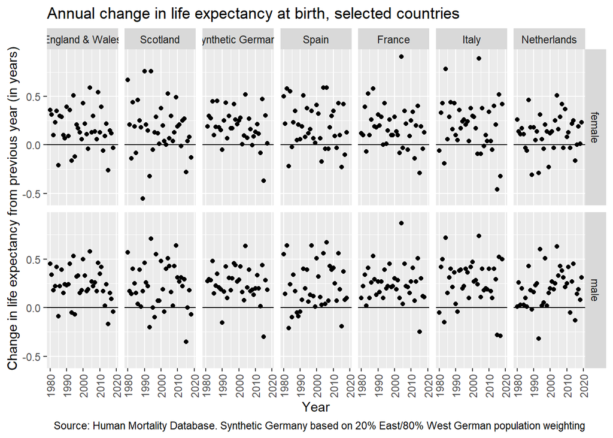

```r
series_of_interest %>%
  filter(x == 0) %>%
  group_by(country, sex) %>%
  arrange(year) %>%
  mutate(delta_ex = ex - lag(ex)) %>%
  filter(!is.na(delta_ex)) %>%
  ggplot(aes(x = year, y = delta_ex)) +
  geom_point() +
  facet_grid(sex ~ country) +
  geom_hline(yintercept = 0) +
  theme(
        axis.text.x = element_text(angle = 90, vjust = 0.5, hjust=1)
  ) +
  labs(
    x = "Year",
    y = "Change in life expectancy from previous year (in years)",
    title = "Annual change in life expectancy at birth, selected countries",
    caption =  "Source: Human Mortality Database. Synthetic Germany based on 20% East/80% West German population weighting"
  )
```

(n.b. the data in this series are shown in years per year, rather than weeks per year as in the main figure)

The equivalent series for e65 is as follows:

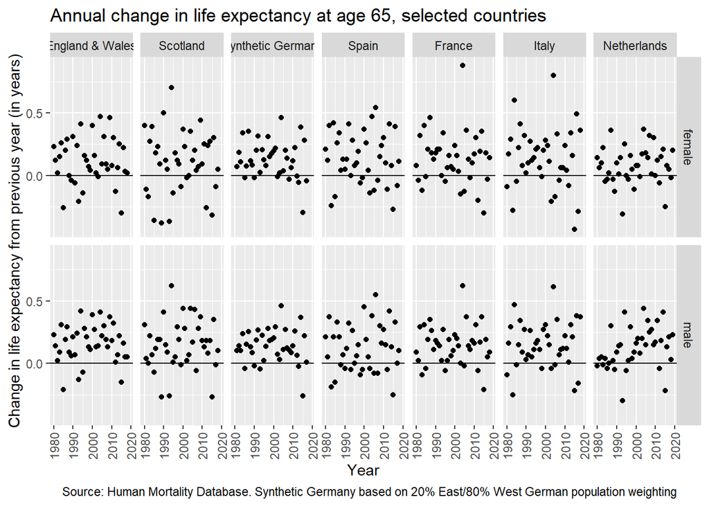

```r
series_of_interest %>%
  filter(x == 65) %>%
  group_by(country, sex) %>%
  arrange(year) %>%
  mutate(delta_ex = ex - lag(ex)) %>%
  filter(!is.na(delta_ex)) %>%
  ggplot(aes(x = year, y = delta_ex)) +
  geom_point() +
  facet_grid(sex ~ country) +
  geom_hline(yintercept = 0) +
  theme(
        axis.text.x = element_text(angle = 90, vjust = 0.5, hjust=1)
  ) +
  labs(
    x = "Year",
    y = "Change in life expectancy from previous year (in years)",
    title = "Annual change in life expectancy at age 65, selected countries",
    caption =  "Source: Human Mortality Database. Synthetic Germany based on 20% East/80% West German population weighting"
  )
```